# Visualisations and Insights from Wrangled Data

```python
# import libraries

import pandas as pd
import numpy as np

import matplotlib.pyplot as plt
%matplotlib inline
```

```python
master_df = pd.read_csv('twitter_archive_master.csv')
```

```python
master_df.head()
```

|  | tweet_id | timestamp | source | text | expanded_urls | rating | name | life_stage | jpg_url | prediction | retweet_count | favorite_count |
| --- | --- | --- | --- | --- | --- | --- | --- | --- | --- | --- | --- | --- |
| 0 | 666020888022790149 | 2015-11-15 22:32:08+00:00 | Twitter for iPhone | Here we have a Japanese Irish Setter. Lost eye... | https://twitter.com/dog_rates/status/666020888... | 8.0 | NaN | NaN | https://pbs.twimg.com/media/CT4udn0WwAA0aMy.jpg | Welsh_springer_spaniel | 532 | 2535 |
| 1 | 666029285002620928 | 2015-11-15 23:05:30+00:00 | Twitter for iPhone | This is a western brown Mitsubishi terrier. Up... | https://twitter.com/dog_rates/status/666029285... | 7.0 | NaN | NaN | https://pbs.twimg.com/media/CT42GRgUYAA5iDo.jpg | redbone | 48 | 132 |
| 2 | 666033412701032449 | 2015-11-15 23:21:54+00:00 | Twitter for iPhone | Here is a very happy pup. Big fan of well-main... | https://twitter.com/dog_rates/status/666033412... | 9.0 | NaN | NaN | https://pbs.twimg.com/media/CT4521TWwAEvMyu.jpg | German_shepherd | 47 | 128 |
| 3 | 666044226329800704 | 2015-11-16 00:04:52+00:00 | Twitter for iPhone | This is a purebred Piers Morgan. Loves to Netf... | https://twitter.com/dog_rates/status/666044226... | 6.0 | NaN | NaN | https://pbs.twimg.com/media/CT5Dr8HUEAA-lEu.jpg | Rhodesian_ridgeback | 147 | 311 |
| 4 | 666049248165822465 | 2015-11-16 00:24:50+00:00 | Twitter for iPhone | Here we have a 1949 1st generation vulpix. Enj... | https://twitter.com/dog_rates/status/666049248... | 5.0 | NaN | NaN | https://pbs.twimg.com/media/CT5IQmsXIAAKY4A.jpg | miniature_pinscher | 41 | 111 |

```python
master_df.info()
```

```
<class 'pandas.core.frame.DataFrame'>
RangeIndex: 1968 entries, 0 to 1967
Data columns (total 12 columns):
 #   Column          Non-Null Count  Dtype
---  ------          --------------  -----
 0   tweet_id        1968 non-null   int64
 1   timestamp       1968 non-null   object
 2   source          1968 non-null   object
 3   text            1968 non-null   object
 4   expanded_urls   1968 non-null   object
 5   rating          1968 non-null   float64
 6   name            1346 non-null   object
 7   life_stage      303 non-null    object
 8   jpg_url         1968 non-null   object
 9   prediction      1663 non-null   object
 10  retweet_count   1968 non-null   int64
 11  favorite_count  1968 non-null   int64
dtypes: float64(1), int64(3), object(8)
memory usage: 184.6+ KB
```

```python
master_df['tweet_id'] = master_df['tweet_id'].astype(object)
master_df['timestamp'] = pd.to_datetime(master_df.timestamp)
master_df['source'] = master_df['source'].astype('category')
master_df['life_stage'] = master_df['life_stage'].astype('category')
```

## Visualisation and Insights

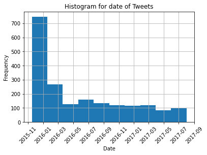

```python
master_df.timestamp.hist()
plt.title('Histogram for date of Tweets')
plt.ylabel('Frequency')
plt.xlabel('Date')
plt.xticks(rotation=45);
```

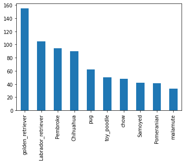

```python
master_df[master_df.prediction.notna()]['prediction'].value_counts()[:10].plot(kind='bar');
```

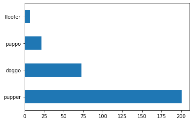

```python
master_df.life_stage.value_counts().plot(kind='barh');
```

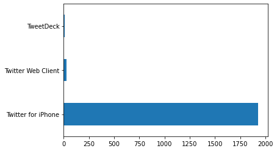

```python
master_df.source.value_counts().plot(kind='barh');
```

```python
master_df.source.value_counts()
```

```
Twitter for iPhone    1929
Twitter Web Client      28
TweetDeck               11
Name: source, dtype: int64
```

```python
master_df.source.value_counts() / master_df.source.count() * 100
```

```
Twitter for iPhone    98.018293
Twitter Web Client     1.422764
TweetDeck              0.558943
Name: source, dtype: float64
```

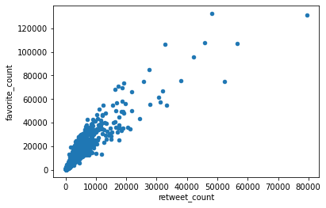

```python
master_df.plot(x='retweet_count', y='favorite_count', kind='scatter');
```

## Insights:

- Most of the popularity of the #WeRateDogs occured at November 2015 - January 2016, then the popularity dropped
- The retriever types are the most dogs owned by people who tweeted
- Most of the dogs owned are puppers, About 200 out of the 303 classified.(quite expected they are cute)
- Most of the tweets are from Iphone, 1929 out of 1968, About 98%
- There is a positive correlation between the favourite count and retweet count

## Conclusion

The WeRateDogs was really popular towards the end of 2015 and beginning of 2016, and the popularity dropped from there, most of the tweets were from iphone users not surprised as most people find it easier tweeting from the app than the web.

Retweets was directly proportional to favourite_count('likes'), quite understandable as more retweet mean they'll reach more users.

The life_stage of the dogs are mostly pupper, and the retriever type of dogs were most common.